# College

**Index** 1. Chapter 2 - Exercise 8

# Chapter 2 - Exercise 8

This exercise relates to the College data set, which can be found in the file College.csv on the book website. It contains a number of variables for 777 different universities and colleges in the US. The variables are

- Private : Public/private indicator
- Apps : Number of applications received
- Accept : Number of applicants accepted
- Enroll : Number of new students enrolled
- Top10perc : New students from top 10 % of high school class
- Top25perc : New students from top 25 % of high school class
- F.Undergrad : Number of full-time undergraduates
- P.Undergrad : Number of part-time undergraduates
- Outstate : Out-of-state tuition
- Room.Board : Room and board costs
- Books : Estimated book costs
- Personal : Estimated personal spending
- PhD : Percent of faculty with Ph.D.’s
- Terminal : Percent of faculty with terminal degree
- S.F.Ratio : Student/faculty ratio
- perc.alumni : Percent of alumni who donate
- Expend : Instructional expenditure per student
- Grad.Rate : Graduation rate

Before reading the data into R , it can be viewed in Excel or a text editor.

1. Use the read.csv() function to read the data into R . Call the loaded data college . Make sure that you have the directory set to the correct location for the data.

```r
College=read.csv('data/College.csv',header=TRUE, na.strings = '?')
```

2. Look at the data using the View() function. You should notice that the first column is just the name of each university. We don’t really want R to treat this as data. However, it may be handy to have these names for later. Try the following commands:

```r
rownames( College ) <- College [ , 1]
View( College )
```

You should see that there is now a row.names column with the name of each university recorded. This means that R has given each row a name corresponding to the appropriate university. R will not try to perform calculations on the row names. However, we still need to eliminate the first column in the data where the names are stored. Try

```r
College <- College [ , -1]
```

```r
View ( College )
```

Now you should see that the first data column is Private . Note that another column labeled row.names now appears before the Private column. However, this is not a data column but rather the name that R is giving to each row.

3. 1. Use the summary() function to produce a numerical summary of the variables in the data set.

```r
summary(College)
```

```
 Private        Apps           Accept          Enroll       Top10perc       Top25perc      F.Undergrad
 No :212   Min.   :   81   Min.   :   72   Min.   :  35   Min.   : 1.00   Min.   :  9.0   Min.   :  139
 Yes:565   1st Qu.:  776   1st Qu.:  604   1st Qu.: 242   1st Qu.:15.00   1st Qu.: 41.0   1st Qu.:  992
           Median : 1558   Median : 1110   Median : 434   Median :23.00   Median : 54.0   Median : 1707
           Mean   : 3002   Mean   : 2019   Mean   : 780   Mean   :27.56   Mean   : 55.8   Mean   : 3700
           3rd Qu.: 3624   3rd Qu.: 2424   3rd Qu.: 902   3rd Qu.:35.00   3rd Qu.: 69.0   3rd Qu.: 4005
           Max.   :48094   Max.   :26330   Max.   :6392   Max.   :96.00   Max.   :100.0   Max.   :31643
  P.Undergrad         Outstate       Room.Board       Books           Personal         PhD
 Min.   :    1.0   Min.   : 2340   Min.   :1780   Min.   :  96.0   Min.   : 250   Min.   :  8.00
 1st Qu.:   95.0   1st Qu.: 7320   1st Qu.:3597   1st Qu.: 470.0   1st Qu.: 850   1st Qu.: 62.00
 Median :  353.0   Median : 9990   Median :4200   Median : 500.0   Median :1200   Median : 75.00
 Mean   :  855.3   Mean   :10441   Mean   :4358   Mean   : 549.4   Mean   :1341   Mean   : 72.66
 3rd Qu.:  967.0   3rd Qu.:12925   3rd Qu.:5050   3rd Qu.: 600.0   3rd Qu.:1700   3rd Qu.: 85.00
 Max.   :21836.0   Max.   :21700   Max.   :8124   Max.   :2340.0   Max.   :6800   Max.   :103.00
    Terminal       S.F.Ratio      perc.alumni        Expend        Grad.Rate
 Min.   : 24.0   Min.   : 2.50   Min.   : 0.00   Min.   : 3186   Min.   : 10.00
 1st Qu.: 71.0   1st Qu.:11.50   1st Qu.:13.00   1st Qu.: 6751   1st Qu.: 53.00
 Median : 82.0   Median :13.60   Median :21.00   Median : 8377   Median : 65.00
 Mean   : 79.7   Mean   :14.09   Mean   :22.74   Mean   : 9660   Mean   : 65.46
 3rd Qu.: 92.0   3rd Qu.:16.50   3rd Qu.:31.00   3rd Qu.:10830   3rd Qu.: 78.00
 Max.   :100.0   Max.   :39.80   Max.   :64.00   Max.   :56233   Max.   :118.00
```

2. Use the pairs() function to produce a scatterplot matrix of the first ten columns or variables of the data. Recall that you can reference the first ten columns of a matrix A using A[,1:10] .

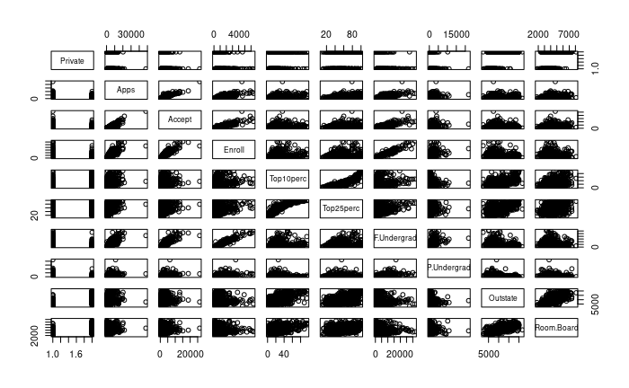

```r
pairs(College[,1:10])
```

3. Use the plot() function to produce side-by-side boxplots of Outstate versus Private .

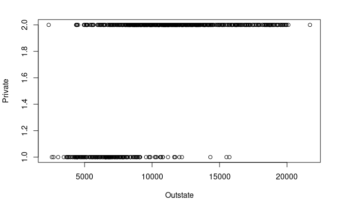

```r
attach(College)
plot(Outstate,Private)
```

4. Create a new qualitative variable, called Elite , by binning the Top10perc variable. We are going to divide universities into two groups based on whether or not the proportion of students coming from the top 10% of their high school classes exceeds 50%.

```r
Elite <- rep( " No " , nrow ( College ) )
Elite [ Top10perc > 50] <- " Yes "
Elite <- as.factor ( Elite )
College <- data.frame ( College , Elite )
```

Use the summary() function to see how many elite universities there are. Now use the plot() function to produce side-by-side boxplots of Outstate versus Elite.

```r
summary(Elite)
```

```
  No   Yes
  699    78
```

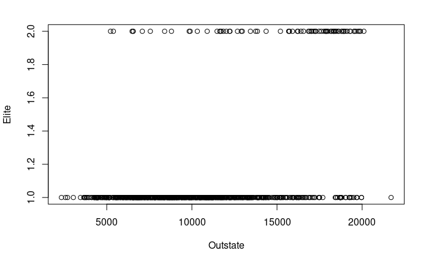

```r
plot(Outstate, Elite)
```

22. Use the hist() function to produce some histograms with differing numbers of bins for a few of the quantitative variables. You may find the command par(mfrow = c(2, 2)) useful: it will divide the print window into four regions so that four plots can be made simultaneously. Modifying the arguments to this function will divide the screen in other ways.

```r
par(mfrow = c(3, 3))
hist(Accept)
hist(F.Undergrad)
```

```r
hist(P.Undergrad)
hist(Books)
```

```r
hist(Personal)
hist(PhD)
```

```r
hist(Terminal)
hist(Expend)
```

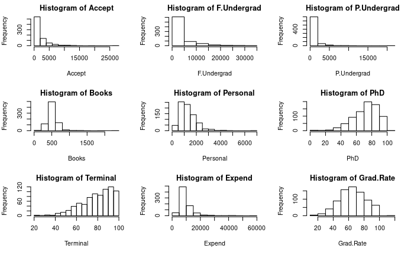

```r
hist(Grad.Rate)
```

6. Continue exploring the data, and provide a brief summary of what you discover.

```r
par(mfrow = c(2, 2))
plot(Books, Terminal)
plot(Books, PhD)
```

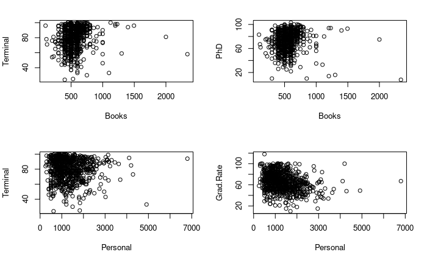

```r
plot(Personal, Terminal)
plot(Personal, Grad.Rate)
```

It seems that neither Books or Personal does not interfere to graduation rate and PhD, but there are some singular values with a lot of personal and/or a lot of books.

```r
par(mfrow = c(2, 2))
plot(Private, Terminal)
plot(Private, PhD)
```

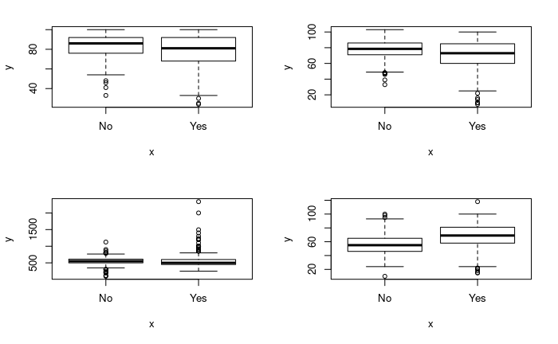

```r
plot(Private, Books)
plot(Private, Grad.Rate)
```